# 2'-Hydroxychalcone and 2'-Hydroxypropenone

Comparison of the two sets of molecules, with $\omega$b97xd/6-311++G** level of theory

# Functions

```python
import matplotlib.pyplot as plt
import numpy as np
from matplotlib.pyplot import cm
%matplotlib inline


def plot_figure(dataset1,dataset2,name,colour,lw,ax):
    ax.scatter(x,dataset1,marker='_',c=colour, s=300,linewidth=1)
    ax.scatter(x,dataset2,marker='_',c=colour, s=300,linewidth=1)
    ax.plot(x,dataset1,linestyle=':',color=colour,linewidth=lw, label=name)
    ax.plot(x,dataset2,linestyle=':',color=colour,linewidth=lw)


def plot_style_A():
    ax.spines['right'].set_visible(False)
    ax.spines['top'].set_visible(False)
    ax.spines['left'].set_linewidth(1.5)
    ax.spines['bottom'].set_visible(False)
    plt.tick_params(axis='x', top='off')
    ax.yaxis.set_ticks_position('left')
    ax.xaxis.set_tick_params(labelsize=12,width=1.5)
    ax.yaxis.set_tick_params(labelsize=12,width=1.5)
    plt.ylabel('Relative Energy (eV)',fontsize=12)
    plt.tight_layout()

def xlabels(labelnames):
    labels = [item.get_text() for item in ax.get_xticklabels()]
    labels = [i for i in labelnames]
    plt.xticks(x, labels,rotation=30,fontsize=10)
def legend_style_horizontal():
    box = ax.get_position()
    ax.set_position([box.x0, box.y0 + box.height * 0.05,
                 box.width, box.height * 0.95])

    ax.legend(loc='upper center', bbox_to_anchor=(0.2, +1.),
            ncol=2,fontsize=10,markerscale=0.75, frameon=False)

def legend_style_vertical():
    box = ax.get_position()
    ax.set_position([box.x0, box.y0 + box.width*0.05,
                 box.width*0.95, box.height])

    ax.legend(loc='best', bbox_to_anchor=(0.2, 1),
            ncol=1,fontsize=10,markerscale=0.75, frameon=False)
```

# Raw Data

### 2HC

#### Vacuum

```python
hc1_s0=np.loadtxt("2hc-1.dat")[:,0]
hc1_s1=np.loadtxt("2hc-1.dat")[:,1]
hc2_s0=np.loadtxt("2hc-2.dat")[:,0]
hc2_s1=np.loadtxt("2hc-2.dat")[:,1]
hc3_s0=np.loadtxt("2hc-3.dat")[:,0]
hc3_s1=np.loadtxt("2hc-3.dat")[:,1]
hc4_s0=np.loadtxt("2hc-4.dat")[:,0]
hc4_s1=np.loadtxt("2hc-4.dat")[:,1]
hc5_s0=np.loadtxt("2hc-5.dat")[:,0]
hc5_s1=np.loadtxt("2hc-5.dat")[:,1]

hc_s0=[hc1_s0,hc2_s0,hc3_s0,hc4_s0,hc5_s0]
hc_s1=[hc1_s1,hc2_s1,hc3_s1,hc4_s1,hc5_s1]
```

#### DCM

```python
hc1_DCM=np.loadtxt("2hc-1-DCM.dat")
hc2_DCM=np.loadtxt("2hc-2-DCM.dat")
hc3_DCM=np.loadtxt("2hc-3-DCM.dat")
hc4_DCM=np.loadtxt("2hc-4-DCM.dat")
hc5_DCM=np.loadtxt("2hc-5-DCM.dat")

hc1_DCM_s0=[(i-hc1_DCM[2,0])*27.2114 for i in hc1_DCM[:,0]]
hc1_DCM_s1=[(i-hc1_DCM[2,0])*27.2114 for i in hc1_DCM[:,1]]
hc2_DCM_s0=[(i-hc2_DCM[2,0])*27.2114 for i in hc2_DCM[:,0]]
hc2_DCM_s1=[(i-hc2_DCM[2,0])*27.2114 for i in hc2_DCM[:,1]]
hc3_DCM_s0=[(i-hc3_DCM[2,0])*27.2114 for i in hc3_DCM[:,0]]
hc3_DCM_s1=[(i-hc3_DCM[2,0])*27.2114 for i in hc3_DCM[:,1]]
hc4_DCM_s0=[(i-hc4_DCM[2,0])*27.2114 for i in hc4_DCM[:,0]]
hc4_DCM_s1=[(i-hc4_DCM[2,0])*27.2114 for i in hc4_DCM[:,1]]
hc5_DCM_s0=[(i-hc5_DCM[2,0])*27.2114 for i in hc5_DCM[:,0]]
hc5_DCM_s1=[(i-hc5_DCM[2,0])*27.2114 for i in hc5_DCM[:,1]]
hc_s0_DCM=[hc1_DCM_s0,hc2_DCM_s0,hc3_DCM_s0,hc4_DCM_s0,hc5_DCM_s0]
hc_s1_DCM=[hc1_DCM_s1,hc2_DCM_s1,hc3_DCM_s1,hc4_DCM_s1,hc5_DCM_s1]
```

### 2HP

#### Vacuum

```python
hp1=np.loadtxt("hp-1.dat")
hp2=np.loadtxt("hp-2.dat")
hp3=np.loadtxt("hp-3.dat")
hp4=np.loadtxt("hp-4.dat")
hp5=np.loadtxt("hp-5.dat")

hp1_s0=[(i-hp1[2,0])*27.2114 for i in hp1[:,0]]
hp1_s1=[(i-hp1[2,0])*27.2114 for i in hp1[:,1]]

hp2_s0=[(i-hp2[2,0])*27.2114 for i in hp2[:,0]]
hp2_s1=[(i-hp2[2,0])*27.2114 for i in hp2[:,1]]

hp3_s0=[(i-hp3[2,0])*27.2114 for i in hp3[:,0]]
hp3_s1=[(i-hp3[2,0])*27.2114 for i in hp3[:,1]]

hp4_s0=[(i-hp4[2,0])*27.2114 for i in hp4[:,0]]
hp4_s1=[(i-hp4[2,0])*27.2114 for i in hp4[:,1]]

hp5_s0=[(i-hp5[2,0])*27.2114 for i in hp5[:,0]]
hp5_s1=[(i-hp5[2,0])*27.2114 for i in hp5[:,1]]

hp_s0=[hp1_s0,hp2_s0,hp3_s0,hp4_s0,hp5_s0]
hp_s1=[hp1_s1,hp2_s1,hp3_s1,hp4_s1,hp5_s1]
```

#### DCM

```python
hp1_DCM=np.loadtxt("hp-1-DCM.dat")
hp1_DCM_s0=[(i-hp1_DCM[2,0])*27.2114 for i in hp1_DCM[:,0]]
hp1_DCM_s1=[(i-hp1_DCM[2,0])*27.2114 for i in hp1_DCM[:,1]]

hp2_DCM=np.loadtxt("hp-2-DCM.dat")
hp2_DCM_s0=[(i-hp2_DCM[2,0])*27.2114 for i in hp2_DCM[:,0]]
hp2_DCM_s1=[(i-hp2_DCM[2,0])*27.2114 for i in hp2_DCM[:,1]]

hp3_DCM=np.loadtxt("hp-3-DCM.dat")
hp3_DCM_s0=[(i-hp3_DCM[2,0])*27.2114 for i in hp3_DCM[:,0]]
hp3_DCM_s1=[(i-hp3_DCM[2,0])*27.2114 for i in hp3_DCM[:,1]]

hp4_DCM=np.loadtxt("hp-4-DCM.dat")
hp4_DCM_s0=[(i-hp4_DCM[2,0])*27.2114 for i in hp4_DCM[:,0]]
hp4_DCM_s1=[(i-hp4_DCM[2,0])*27.2114 for i in hp4_DCM[:,1]]

hp5_DCM=np.loadtxt("hp-5-DCM.dat")
hp5_DCM_s0=[(i-hp5_DCM[2,0])*27.2114 for i in hp5_DCM[:,0]]
hp5_DCM_s1=[(i-hp5_DCM[2,0])*27.2114 for i in hp5_DCM[:,1]]


hp_DCM_s0=[hp1_DCM_s0,hp2_DCM_s0,hp3_DCM_s0,hp4_DCM_s0,hp5_DCM_s0]
hp_DCM_s1=[hp1_DCM_s1,hp2_DCM_s1,hp3_DCM_s1,hp4_DCM_s1,hp5_DCM_s1]
```

# Experimental observations

Publications:

2HP: Zhang et. al. *Chem. Commun.*, **2016**, 52, 6577-6580  
2HC: Zhang et. al. *Ang. Chem. Int.Ed.*, **2015**, 54, 8369–8373

**2HP**:

# Analysis

## Vacuum

First we analyse the energies in vacuum of 2HP and 2HC molecules:

### 2HP

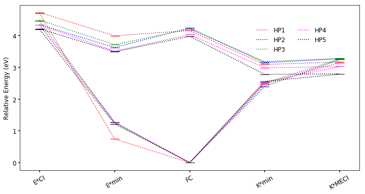

```python
fig,ax=plt.subplots(figsize=(12,6))
colours=['red','blue','green','magenta','black']

x=range(len(hp1_s0))

for i in range(len(hp_s0[:4])):

    plot_figure(hp_s0[i],hp_s1[i],'HP'+str(i+1),colours[i],1.5,ax)
x=[0,1,2,3,4]
plot_figure(hp_s0[4],hp_s1[4],'HP'+str(4+1),colours[4],1.5,ax)
labelnames=["E*CI","E*min","FC","K*min","K*MECI"]
xlabels(labelnames)
ax.xaxis.set_tick_params(labelsize=12,width=1.5)
ax.yaxis.set_tick_params(labelsize=12,width=1.5)
plt.ylabel('Relative Energy (eV)',fontsize=12)
ax.legend(loc='upper center', bbox_to_anchor=(0.8, +0.9),
            ncol=2,fontsize=12,markerscale=0.2, frameon=False)
```

Now we have a good picture of the mechanism for each 2HP compound. Lets deconstruct the process with a view to the effect of the substituents.

#### Vertical Excitations

```python
hp_VE=[i[2] for i in hp_s1]
for i in range(len(hp_VE)):
    print("{}HP: {:.2f} eV".format(i+1,hp_VE[i]))
print("Mean: {:.2f} eV\nStandard deviation {:.2f}".format(np.mean(hp_VE),np.std(hp_VE)))
```

```
1HP: 4.16 eV
2HP: 4.24 eV
3HP: 4.21 eV
4HP: 4.04 eV
5HP: 3.98 eV
Mean: 4.13 eV
Standard deviation 0.10
```

```
(3, 4.5)
```

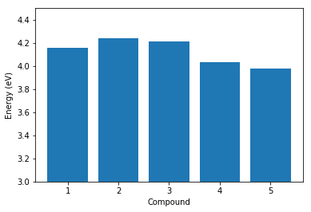

```python
fig,ax=plt.subplots()
ax.bar(range(1,6),hp_VE)
plt.xlabel("Compound")
plt.ylabel("Energy (eV)")
plt.ylim(3,4.5)
```

A quick reminder of the substituents:

1. H
2. m-F
3. m-OCH3
4. p-F
5. p-OCH3

Evidently, substitution at meta-position destabilises the S${_1}$ vertical excitation energy, whilst the para position stablises, with respect to compound **1**. Methoxy in para stablises the most (**5**). These excitations are all to S1, bright, and HOMO-LUMO in character. The difference density plots show that density is lost from the phenol right oxygen and donated to the C=O carboynl. In 2 and three, there is some donation from the amino N. In 4, electron density is lost from the F. **5** involves large donation from the methoxy group and large antibonding character in the C=C double bond, explaining the stability of the Enol ZtoE minumum.

#### Deactivation Pathways

Relaxation in S${_1}$ from the FC point results in ESIPT for all five systems. This can be rationalised by the increased basicity of the carbonyl oxygen, and the acidity of the proton by the loss of electron density from the phenol oxygen. ESIPT is followed by intramolecular rotation of the phenoxy ring, resulting in a large stablisation of the KS${_1}$ state. Stablisation energy wrt FC VE:

```python
for i in range(5):
    print("Compound {}: K*min - VE = {} eV".format(i+1,(hp_s1[i][3]-hp_VE[i]).round(3)))
```

```
Compound 1: K*min - VE = -1.069 eV
Compound 2: K*min - VE = -1.09 eV
Compound 3: K*min - VE = -1.034 eV
Compound 4: K*min - VE = -1.047 eV
Compound 5: K*min - VE = -1.198 eV
```

The KS${_1}$ conical intersection is then almost degenerate with the Kminimum.

So, ESIPT will be the heavily-favoured mechanism for each of compounds **1**-**5**. However, we were able to locate several minima in the Enol channel. One pathway involves intramolecular rotation to the trans-Enol form, whilst there also exist minima and approx. 30 degrees rotation in the cis-Enol form. However, the lowest energy minimum for each compound involves pyramidalisation of the unsaturated chain of the molecule, in an Z to E 90degree twist. The LUMO orbital becomes antibonding across this bond, rationalising this behaviour. However, this mechanism will almost certainly be secondary to the ESIPT process. A rudimentary scan of this rotation at the 3-21(d) level shows a barrier of at least 0.2 eV for this mode. There is an associated conical intersection in this channel for all except **3**, which couldnt be converged (final gap = 0.03 eV)

#### Potential energy surfaces

Relaxed geometry scans of the dihedral angle in the Keto S1 state were performed for **1**-**4**

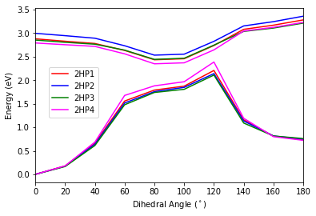

```python
scanpath="/Users/michaeldommett/phdwork/proton_transfer/Matt_msci/2HCvs2HP/Scans/"
fig,ax=plt.subplots()
plt.xlabel("Dihedral Angle ($^\circ$)")
plt.ylabel("Energy (eV)")
plt.xlim(0,180)
for i in range(4):
    energies=np.loadtxt(scanpath+str(i+1)+"_scan_vacuum.out-energies")
    x=np.arange(0,len(energies[:,1])*20,20)
    ax.plot(x,energies[:,1],color=colours[i],label="2HP"+str(i+1))
    ax.plot(x,energies[:,0],color=colours[i])
plt.legend(bbox_to_anchor=(0.25, +0.35))
```

### 2HC

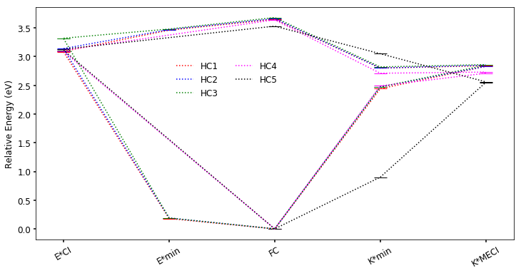

```python
fig,ax=plt.subplots(figsize=(12,6))
colours=['red','blue','green','magenta','black']

x=range(len(hp1_s0))
labelnames=["E*CI","E*min","FC","K*min","K*MECI"]
xlabels(labelnames)
for i in range(len(hc_s0[:3])):

    plot_figure(hc_s0[i],hc_s1[i],'HC'+str(i+1),colours[i],1.5,ax)
x=[0,2,3,4]
plot_figure(hc_s0[3],hc_s1[3],'HC'+str(3+1),colours[3],1.5,ax)
plot_figure(hc_s0[4],hc_s1[4],'HC'+str(4+1),colours[4],1.5,ax)

ax.xaxis.set_tick_params(labelsize=12,width=1.5)
ax.yaxis.set_tick_params(labelsize=12,width=1.5)
plt.ylabel('Relative Energy (eV)',fontsize=12)
ax.legend(loc='upper center', bbox_to_anchor=(0.4, +0.8),
            ncol=2,fontsize=12,markerscale=0.2, frameon=False)
```

#### Vertical excitations

```python
hc_VE=[i[2] for i in hc_s1[:3]]
hc_VE.append(hc4_s1[1])
hc_VE.append(hc5_s1[1])
for i in range(len(hc_VE)):
    print("{}HC: {:.2f} eV".format(i+1,hc_VE[i]))
print("Mean: {:.2f} eV\nStandard deviation {:.2f}".format(np.mean(hc_VE),np.std(hc_VE)))
```

```
1HC: 3.65 eV
2HC: 3.66 eV
3HC: 3.68 eV
4HC: 3.64 eV
5HC: 3.53 eV
Mean: 3.63 eV
Standard deviation 0.05
```

The vertical excitation energies are insensitive to the substituent unless there is a strong donor in the para position, which stablises S${_1}$. This is also observed in 2HP-5.

#### Potential Energy Surfaces

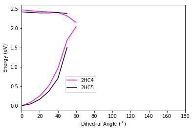

```python
scanpath="/Users/michaeldommett/phdwork/proton_transfer/Matt_msci/2HCvs2HP/Scans/2HC/"
fig,ax=plt.subplots()
plt.xlabel("Dihedral Angle ($^\circ$)")
plt.ylabel("Energy (eV)")
plt.xlim(0,180)
for i in [3,4]:
    energies=np.loadtxt(scanpath+str(i+1)+"_scan_vacuum.out-energies")
    x=np.arange(0,len(energies[:,1])*10,10)
    ax.plot(x,energies[:,1],color=colours[i],label="2HC"+str(i+1))
    ax.plot(x,energies[:,0],color=colours[i])
plt.legend(bbox_to_anchor=(0.25, +0.35))
```

## DCM

### 2-HP

```
[4.447365690946703, 1.0960099662724552, 0.0, 0.48800018620286612, 3.9185630989000839]
[4.7588194296209023, 1.0925758059603641, 0.0, 0.42849791580089908, 3.9675935518201042]
[4.5788377877393192, 1.3134153649393325, 0.0, 0.47596820310015087, 3.9899286689381608]
[4.2863342857212388, 1.095718722660163, 0.0, 0.49453454131998842, 3.8117674697221897]
[4.4175219145365663, 1.1032615594711508, 0.0, 0.60539283252340259, 3.7377539311358796]
```

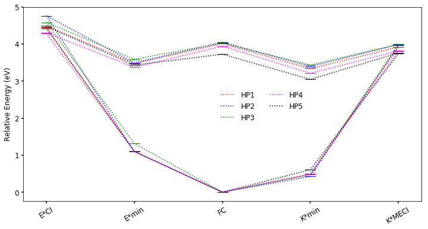

```python
fig,ax=plt.subplots(figsize=(12,6))
colours=['red','blue','green','magenta','black']

x=range(len(hp1_s0))

#for i in range(len(hp_DCM_s0)):
for i in range(len(hp_DCM_s0)):
    plot_figure(hp_DCM_s0[i],hp_DCM_s1[i],'HP'+str(i+1),colours[i],1.5,ax)
    print(hp_DCM_s0[i])
labelnames=["E*CI","E*min","FC","K*min","K*MECI"]
xlabels(labelnames)
ax.xaxis.set_tick_params(labelsize=12,width=1.5)
ax.yaxis.set_tick_params(labelsize=12,width=1.5)
plt.ylabel('Relative Energy (eV)',fontsize=12)
ax.legend(loc='upper center', bbox_to_anchor=(0.6, +0.6),
            ncol=2,fontsize=12,markerscale=0.2, frameon=False)
```

#### Vertical excitation energies

```python
hp_DCM_VE=[(i[2]) for i in hp_DCM_s1]
for i in range(len(hp_DCM_VE)):
    print("{}HP: {:.2f} eV, shift vs vacuum: {:.2f} eV".format(i+1,hp_DCM_VE[i],hp_DCM_VE[i]-hp_VE[i]))
print("Mean: {:.2f} eV\nStandard deviation {:.2f}".format(np.mean(hp_DCM_VE),np.std(hp_DCM_VE)))
```

```
1HP: 4.01 eV, shift vs vacuum: -0.15 eV
2HP: 4.05 eV, shift vs vacuum: -0.19 eV
3HP: 4.03 eV, shift vs vacuum: -0.19 eV
4HP: 3.94 eV, shift vs vacuum: -0.09 eV
5HP: 3.72 eV, shift vs vacuum: -0.26 eV
Mean: 3.95 eV
Standard deviation 0.12
```

#### Deactivation mechanisms and fluorescence

Only keto emission is expected to be observed from experimental data. The computational results also predict this, since the osillator strength *f* from the Eminimum is <0.001. Keto flourescence energies in DCM (experimental):

```python
hp_Kfluo_exp=[2.42,2.55,2.57,2.37]
for i in range(len(hp_DCM_s1)-1):
    print("{}HP DCM: {:.3f} eV ({})".format(i+1,hp_DCM_s1[i][3]-hp_DCM_s0[i][3],hp_Kfluo_exp[i]))
print("5HP DCM: {:.3f} eV (NA)".format(hp_DCM_s1[4][3]-hp_DCM_s0[4][3]))
```

```
1HP DCM: 2.846 eV (2.42)
2HP DCM: 2.967 eV (2.55)
3HP DCM: 2.955 eV (2.57)
4HP DCM: 2.715 eV (2.37)
5HP DCM: 2.440 eV (NA)
```

The keto minima remain planar, unlike in vacuum. The predicted emission energies are overestimated by ~0.4 eV overestimated vs the experimental data. The oscillator strengths all in the range 0.6-0.8, showing fluorescence can be expected from these compounds. The PES scans, below, show why

#### Potential Energy surfaces

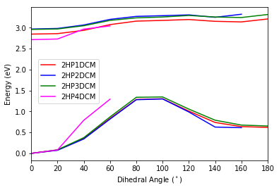

```python
scanpath="/Users/michaeldommett/phdwork/proton_transfer/Matt_msci/2HCvs2HP/Scans/"
fig,ax=plt.subplots()
plt.xlabel("Dihedral Angle ($^\circ$)")
plt.ylabel("Energy (eV)")
plt.xlim(0,180)
for i in range(4):
    energies=np.loadtxt(scanpath+str(i+1)+"_scan_solvated.out-energies")
    x=np.arange(0,len(energies[:,1])*20,20)
    ax.plot(x,energies[:,1],color=colours[i],label="2HP"+str(i+1)+"DCM")
    ax.plot(x,energies[:,0],color=colours[i])
plt.legend(bbox_to_anchor=(0.3, +0.35))
```

Unlike it vacuum, to rotate on the S1 surface is unfavourable, and so the geometry remains planar. Furthermore, at the 90degree angle the energy gap between S0 and S1 is much larger than in vacuum.

NB: Scan of **4** not complete

The vacuum and solvated plots (for compounds **1**-**4**) are shown below, showing clearly the effect of the solvent on the PES and why there is some fluorescence in DCM.

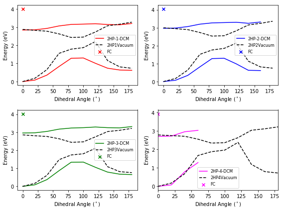

```python
scanpath="/Users/michaeldommett/phdwork/proton_transfer/Matt_msci/2HCvs2HP/Scans/"
axs=["ax1","ax2","ax3","ax4"]
fig,((axs[0],axs[1]),(axs[2],axs[3]))=plt.subplots(ncols=2,nrows=2,figsize=(8,6))

plt.xlim(0,180)
for i in range(4):
    solvated=np.loadtxt(scanpath+str(i+1)+"_scan_solvated.out-energies")
    x=np.arange(0,len(solvated[:,1])*20,20)
    axs[i].scatter(0,hp_DCM_VE[i],color=colours[i],marker='x', label="FC")
    axs[i].plot(x,solvated[:,1],color=colours[i],label="2HP-"+str(i+1)+"-DCM")
    axs[i].plot(x,solvated[:,0],color=colours[i])
    vacuum=np.loadtxt(scanpath+str(i+1)+"_scan_vacuum.out-energies")
    x=np.arange(0,len(vacuum[:,1])*20,20)
    axs[i].plot(x,vacuum[:,1],"--k",label="2HP"+str(i+1)+"Vacuum")
    axs[i].plot(x,vacuum[:,0],"--k")
    axs[i].set_xlabel("Dihedral Angle ($^\circ$)")
    axs[i].set_ylabel("Energy (eV)")
    axs[i].legend(fontsize=8)
plt.tight_layout()
```

### 2HC

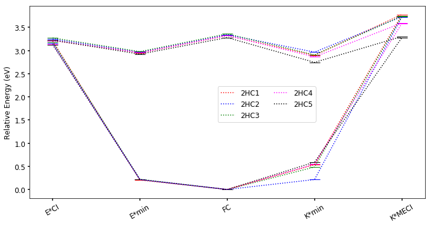

```python
fig,ax=plt.subplots(figsize=(12,6))
colours=['red','blue','green','magenta','black']

x=range(len(hc1_s0))

for i in range(len(hc_s0_DCM)):

    plot_figure(hc_s0_DCM[i],hc_s1_DCM[i],'2HC'+str(i+1),colours[i],1.5,ax)

labelnames=["E*CI","E*min","FC","K*min","K*MECI"]
xlabels(labelnames)
ax.xaxis.set_tick_params(labelsize=12,width=1.5)
ax.yaxis.set_tick_params(labelsize=12,width=1.5)
plt.ylabel('Relative Energy (eV)',fontsize=12)
ax.legend(loc='upper center', bbox_to_anchor=(0.6, +0.6),
            ncol=2,fontsize=12,markerscale=0.2)
```

#### Vertical Excitations

```python
hc_DCM_VE=[(i[2]) for i in hc_s1_DCM]
for i in range(len(hc_DCM_VE)):
    print("{}HC: {:.2f} eV, shift vs vacuum: {:.2f} eV".format(i+1,hc_DCM_VE[i],hc_DCM_VE[i]-hc_VE[i]))
print("Mean: {:.2f} eV\nStandard deviation {:.2f}".format(np.mean(hc_DCM_VE),np.std(hc_DCM_VE)))
```

```
1HC: 3.32 eV, shift vs vacuum: -0.33 eV
2HC: 3.34 eV, shift vs vacuum: -0.32 eV
3HC: 3.36 eV, shift vs vacuum: -0.32 eV
4HC: 3.33 eV, shift vs vacuum: -0.31 eV
5HC: 3.28 eV, shift vs vacuum: -0.25 eV
Mean: 3.33 eV
Standard deviation 0.03
```

#### Fluorescence

```python
for i in range(len(hc_s1_DCM)):
    print("{}HC DCM: {:.3f} eV".format(i+1,hc_s1_DCM[i][3]-hc_s0_DCM[i][3]))
```

```
1HC DCM: 2.361 eV
2HC DCM: 2.752 eV
3HC DCM: 2.422 eV
4HC DCM: 2.316 eV
5HC DCM: 2.154 eV
```

#### Potential energy surfaces

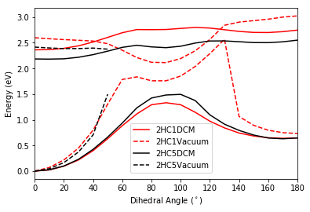

```python
scanpath="/Users/michaeldommett/phdwork/proton_transfer/Matt_msci/2HCvs2HP/Scans/2HC/"
fig,ax=plt.subplots()
plt.xlabel("Dihedral Angle ($^\circ$)")
plt.ylabel("Energy (eV)")
plt.xlim(0,180)
for i in [0,4]:
    solv_energies=np.loadtxt(scanpath+str(i+1)+"_scan_dcm.out-energies")
    x=np.arange(0,len(solv_energies[:,1])*10,10)
    ax.plot(x,solv_energies[:,1],color=colours[i],label="2HC"+str(i+1)+"DCM")
    ax.plot(x,solv_energies[:,0],color=colours[i])

    vac_energies=np.loadtxt(scanpath+str(i+1)+"_scan_vacuum.out-energies")
    x=np.arange(0,len(vac_energies[:,1])*10,10)
    ax.plot(x,vac_energies[:,1],color=colours[i],linestyle="dashed",label="2HC"+str(i+1)+"Vacuum")
    ax.plot(x,vac_energies[:,0],color=colours[i],linestyle="dashed")
plt.legend(bbox_to_anchor=(0.35, +0.35))
```

The solvent has the effect of destabilising the rotation route, making the planar structure stable and thus making fluorescence with high oscillator strength possible. With increasing rotation angle, the oscillator strength tends to 0. For **5**, the KCI is lower in energy (just 0.02 above the S1 vertical excitation) than for **1** - the MECI could still be accessed

```python
hc5_DCM_s1
```

```
[3.2256589754175273,
 2.9229729130969448,
 3.2811375505274123,
 2.7452584162170242,
 3.3030754084200589]
```